# Similarity and Cinderella Teams

2020-04-30

```r
library(tidyverse)
library(scales)
library(gridExtra)
library(knitr)
library(ggExtra)
library(igraph)

# set up plotting theme
theme_jason <- function(legend_pos="top", base_size=12, font=NA){

  # come up with some default text details
  txt <- element_text(size = base_size+3, colour = "black", face = "plain")
  bold_txt <- element_text(size = base_size+3, colour = "black", face = "bold")

  # use the theme_minimal() theme as a baseline
  theme_minimal(base_size = base_size, base_family = font)+
    theme(text = txt,
          # axis title and text
          axis.title.x = element_text(size = 15, hjust = 1),
          axis.title.y = element_text(size = 15),
          # gridlines on plot
          panel.grid.major = element_line(linetype = 2),
          panel.grid.minor = element_line(linetype = 2),
          # title and subtitle text
          plot.title = element_text(size = 18, colour = "grey25", face = "bold"),
          plot.subtitle = element_text(size = 16, colour = "grey44"),

          ###### clean up!
          legend.key = element_blank(),
          # the strip.* arguments are for faceted plots
          strip.background = element_blank(),
          strip.text = element_text(face = "bold", size = 13, colour = "grey35")) +

    #----- AXIS -----#
    theme(
      #### remove Tick marks
      axis.ticks=element_blank(),

      ### legend depends on argument in function and no title
      legend.position = legend_pos,
      legend.title = element_blank(),
      legend.background = element_rect(fill = NULL, size = 0.5,linetype = 2)

    )
}


plot_cols <- c("#498972", "#3E8193", "#BC6E2E", "#A09D3C", "#E06E77", "#7589BC", "#A57BAF", "#4D4D4D")
```

**Key Takeaways**

In this analysis my goal was to identify what factors contribute to the success of underdog teams. The key traits of cinderella teams that pulled of upsets in the past are: 1) They are strong defensively, 2) Create extra possessions by creating turnovers and by crashing the boards. 3) They tend to play a high risk high reward style of game. But there are some traits cannot be quantified in terms of offensive and defensive stats moreover, overall success in the tournament correlates with offensive rebounds and turnover and it is not limited just to underdogs. Statistics like Offensive rebounds tells us that teams that secures more rebounds wins more often than not. Whereas a more local insight can be obtained by comparing teams that had success in previous tournaments. This local insight tells us how similar a given team is to past successful teams and given the similarity, what is the probability that they can pull off an upset. The similarity approach yields some interesting results as we try to infer why some of the upsets occurred. Especially the historic 16 vs 1 upset that occurred in 2018. This approach when combined with a more global approach that uses box statistics provides us with an effective way to quantify success. The model has a good performance in terms of precision and recall based on back testing the model on the past four tournaments. The model has a precision of 62 percent, while also identifying 75 percent of upsets in the first round.

# 1 Introduction

Every year basketball fans around the globe hope that at least one underdog team coming out of nowhere makes a deep run in the tournament, busting millions of brackets as a result. March madness grew into a most watched sporting event not because of pedigree schools like Kansas, Duke or UNC, its because of the little know programs who make improbable runs. What makes march madness so exciting? Its probably because of the number of upsets that occur every year. However, upon closer examination, the structure of the NCAA tournament is designed for upsets as noted by [Erik Johansson](http://harvardsportsanalysis.org/2019/03/march-madness-the-stats-behind-cinderella-stories/). Looking at the tournament data from 2003-2018, after the first two rounds of the tournament, we notice something interesting. As the tournament progresses, there are more 11 seeds remaining than 8,9 or 10 seeds.

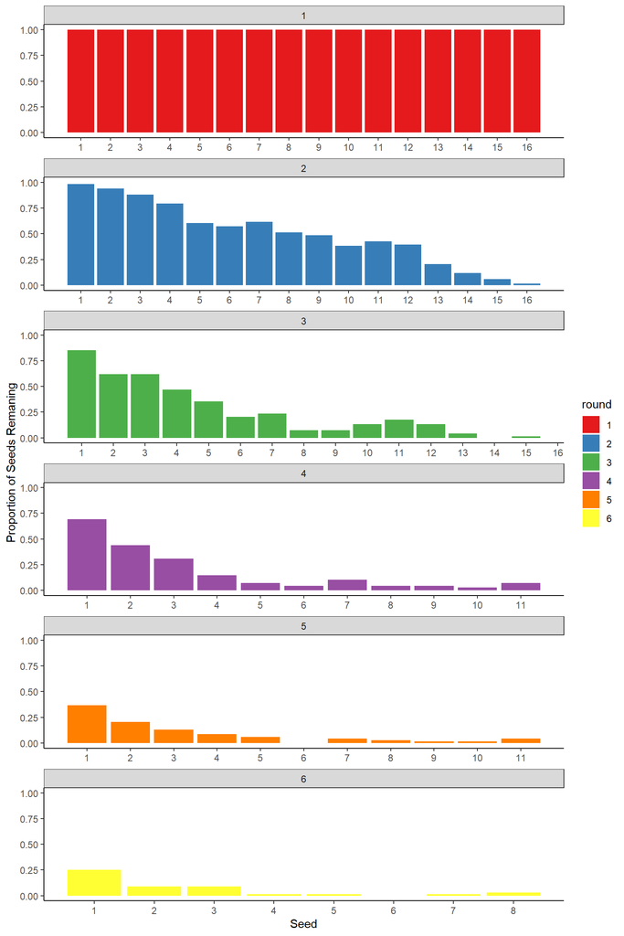

```r
library(pander)
library(dplyr)
library(kableExtra)
library(mlr)
library(igraph)
library(data.table)
library(matrixStats)
library(ggplot2)
sub = fread("MNCAATourneyCompactResults.csv")
finalStats = fread("finaStats.csv")
finalStats = finalStats[,-c(100:102)]
seeds   <- read.csv("NCAATourneySeeds.csv", stringsAsFactors = F)
slots   <- read.csv("NCAATourneySlots.csv", stringsAsFactors = F)
teams   <- read.csv("Teams.csv", stringsAsFactors = F)#read.csv("Sub_2014_2018.csv")
names(sub)[3] <- "team1"
names(sub)[5] <- "team2"
#sub <- read.csv("Test_Bounds.csv")
SeedRoundSlots <- read.csv("SeedRoundSlots.csv")
#sub$Season <- as.numeric(substr(sub$ID, 1, 4))
#sub$team1  <- as.numeric(substr(sub$ID, 6, 9))
#sub$team2  <- as.numeric(substr(sub$ID, 11, 14))

colnames(teams)[2] <- "teamName1"
sub <- merge(sub, teams[,c(1,2)], by.x = c("team1"), by.y = c("TeamID"), all.x = T)
colnames(teams)[2] <- "teamName2"
sub <- merge(sub, teams[,c(1,2)], by.x = c("team2"), by.y = c("TeamID"), all.x = T)
# Seeds
colnames(seeds)[2] <- "Seed1"
sub <- merge(sub, seeds, by.x = c("team1", "Season"), by.y = c("TeamID", "Season"), all.x = T)
colnames(seeds)[2] <- "Seed2"
sub <- merge(sub, seeds, by.x = c("team2", "Season"), by.y = c("TeamID", "Season"), all.x = T)

findMatchupRound <- function(seed1, seed2){
  team1Rounds   <- unique(SeedRoundSlots$game_slot[which(SeedRoundSlots$seed == seed1)])
  team2Rounds   <- unique(SeedRoundSlots$game_slot[which(SeedRoundSlots$seed == seed2)])
  intersection  <- team1Rounds[which(team1Rounds %in% team2Rounds)]
  intersectionNum <- SeedRoundSlots$game_round[which(SeedRoundSlots$game_slot %in% intersection)]
  return(min(intersectionNum))
}


## Distance difference variable
## Add the slot data to the data frame (we need slots so we can add tourneyGeog to this too)
sub$round <- NULL
for(i in 1:nrow(sub)){
  sub$round[i] <- findMatchupRound(sub$Seed1[i],sub$Seed2[i])
}

sub$Seed1 = as.numeric(substring(sub$Seed1,2,3))
sub$Seed2 = as.numeric(substring(sub$Seed2,2,3))
sub1=as.data.frame(sub[,c("Season","team1","round")])
sub2=as.data.frame(sub[,c("Season","team2","round")])
names(sub1)[2] <- "TeamID"
names(sub2)[2] <- "TeamID"
sub_ = rbind(sub1,sub2)


fstats = finalStats[,c("Season","TeamID","Seed")]

fstat1 = inner_join(sub_,fstats,by=c("Season","TeamID"))
fstat = fstat1[!duplicated(fstat1[c("Season","TeamID","round","Seed")]),]


fstat_ = fstat  %>% group_by(round,Seed) %>% summarise(n=length(Seed))
fstat_ = fstat_[fstat_$round >0,]
fstat_$n = fstat_$n/68
ggplot(data=fstat_, aes(x=Seed,y=n,fill=factor(round))) + geom_bar(stat = "identity")+ facet_wrap(~ round,ncol = 1,nrow=6,scales = "free_x") + scale_x_continuous(breaks=seq(1,16,1)) +   scale_fill_brewer(palette = "Set1", name = "round") + labs(y="Proportion of Seeds Remaning") +  theme_bw() + theme(panel.border = element_blank(), panel.grid.major = element_blank(),panel.grid.minor = element_blank(), axis.line = element_line(colour = "black"))
```

It strikes as odd initially, but when we take a look at the bracket, it is pretty evident that 8,9 seeds most likely run into the number 1 seed in the second round, except in 2018! Which means, 10 and 11 seeded teams don’t face the number 1 seed until the sweet sixteen. The structure of the bracket itself is designed to generate upsets.

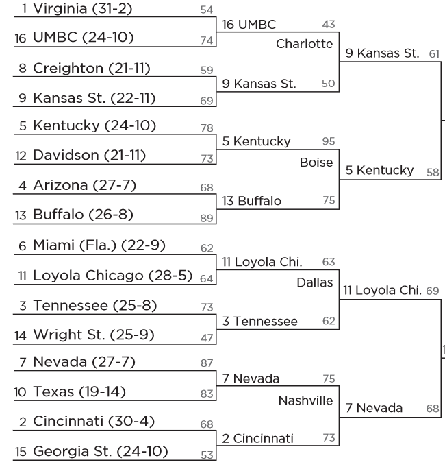

```r
knitr::include_graphics("Bracket.PNG")
```

Looking at the Kenpom adjusted efficiency rating across seeds, we notice that the drop off in Net efficiency from 1-2 seed is much higher when compared to seeds 6-11. Which might possibly explain why we observe a large number of 10-7 and 11-6 upsets.

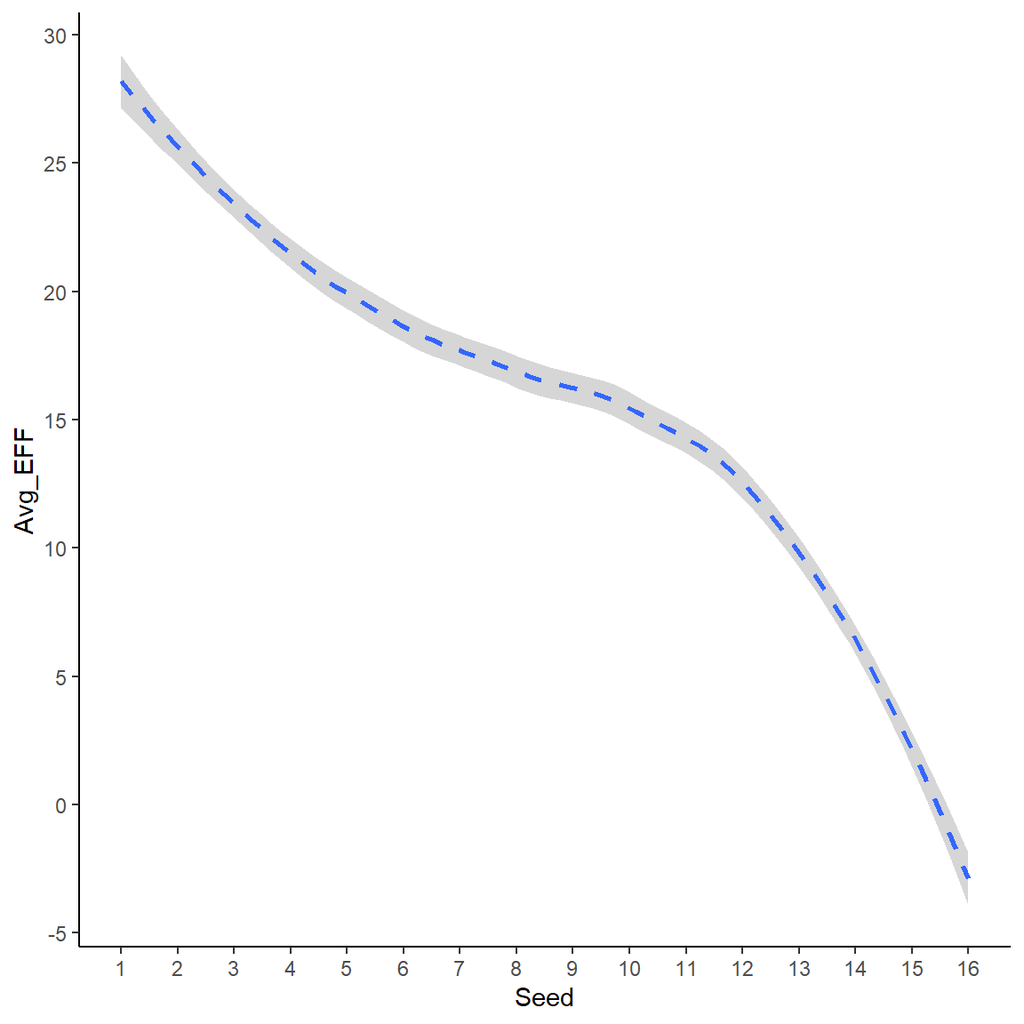

```r
eff = finalStats %>% group_by(Seed) %>% summarise(Avg_EFF = mean(EM))


ggplot(eff, aes(x=Seed, y=Avg_EFF)) + geom_smooth( method=loess, se=TRUE, linetype="dashed", size=1 ) + scale_x_continuous(breaks=seq(1,16,1)) + scale_y_continuous(breaks=seq(-10,30,5)) + theme_bw() + theme(panel.border = element_blank(), panel.grid.major = element_blank(),panel.grid.minor = element_blank(), axis.line = element_line(colour = "black"))
```

```r
sub = fread("MNCAATourneyCompactResults.csv")
seeds   <- read.csv("NCAATourneySeeds.csv", stringsAsFactors = F)
slots   <- read.csv("NCAATourneySlots.csv", stringsAsFactors = F)
teams   <- read.csv("Teams.csv", stringsAsFactors = F)#read.csv("Sub_2014_2018.csv")
names(sub)[3] <- "team1"
names(sub)[5] <- "team2"
#sub <- read.csv("Test_Bounds.csv")
SeedRoundSlots <- read.csv("SeedRoundSlots.csv")
#sub$Season <- as.numeric(substr(sub$ID, 1, 4))
#sub$team1  <- as.numeric(substr(sub$ID, 6, 9))
#sub$team2  <- as.numeric(substr(sub$ID, 11, 14))

colnames(teams)[2] <- "teamName1"
sub <- merge(sub, teams[,c(1,2)], by.x = c("team1"), by.y = c("TeamID"), all.x = T)
colnames(teams)[2] <- "teamName2"
sub <- merge(sub, teams[,c(1,2)], by.x = c("team2"), by.y = c("TeamID"), all.x = T)
# Seeds
colnames(seeds)[2] <- "Seed1"
sub <- merge(sub, seeds, by.x = c("team1", "Season"), by.y = c("TeamID", "Season"), all.x = T)
colnames(seeds)[2] <- "Seed2"
sub <- merge(sub, seeds, by.x = c("team2", "Season"), by.y = c("TeamID", "Season"), all.x = T)

findMatchupRound <- function(seed1, seed2){
  team1Rounds   <- unique(SeedRoundSlots$game_slot[which(SeedRoundSlots$seed == seed1)])
  team2Rounds   <- unique(SeedRoundSlots$game_slot[which(SeedRoundSlots$seed == seed2)])
  intersection  <- team1Rounds[which(team1Rounds %in% team2Rounds)]
  intersectionNum <- SeedRoundSlots$game_round[which(SeedRoundSlots$game_slot %in% intersection)]
  return(min(intersectionNum))
}


## Distance difference variable
## Add the slot data to the data frame (we need slots so we can add tourneyGeog to this too)
sub$round <- NULL
for(i in 1:nrow(sub)){
  sub$round[i] <- findMatchupRound(sub$Seed1[i],sub$Seed2[i])
}

sub$Seed1 = as.numeric(substring(sub$Seed1,2,3))
sub$Seed2 = as.numeric(substring(sub$Seed2,2,3))

sub = sub[,c(2,3,1,11,12,13)]

names(sub)[2] = "TeamID"

finalStats_EM = finalStats[,c("Season","TeamID","EM")]

sub = inner_join(sub,finalStats_EM,c("Season","TeamID"))

names(sub)[3] = "TeamID"
names(sub)[2]<- "Team1"
names(sub)[7] <- "EM_A"


sub = inner_join(sub,finalStats_EM,c("Season","TeamID"))

names(sub)[8] <- "EM_B"

sub$EM = sub$EM_B - sub$EM_A

sub = sub[,c(1,2,3,4,5,6,7,8)]

sub = sub[sub$round == 1 & sub$Seed1 %in% c(7,10),]

sub1 = sub[,c(2,4,7)]

sub2 = sub[,c(3,5,8)]

sub1$ID = rep("W",nrow(sub1))

sub2$ID = rep("L",nrow(sub2))

names(sub1) <- names(sub2) <- c("TeamID","Seed","EM","ID")

sub_EM = rbind(sub1,sub2)

p1=ggplot(data=sub_EM, aes(x=as.factor(Seed),y=EM,fill=factor(ID))) + geom_violin(position = position_dodge(0),alpha=0.5,trim=T) +  geom_boxplot(width = 0.1,position = position_dodge(0),alpha=0.5) +
facet_wrap(~ Seed,scales = "free_x") +   scale_fill_brewer(palette = "Set1") + labs(y="") + theme_bw() + theme(panel.border = element_blank(), panel.grid.major = element_blank(),panel.grid.minor = element_blank(), axis.line = element_line(colour = "black"))
```

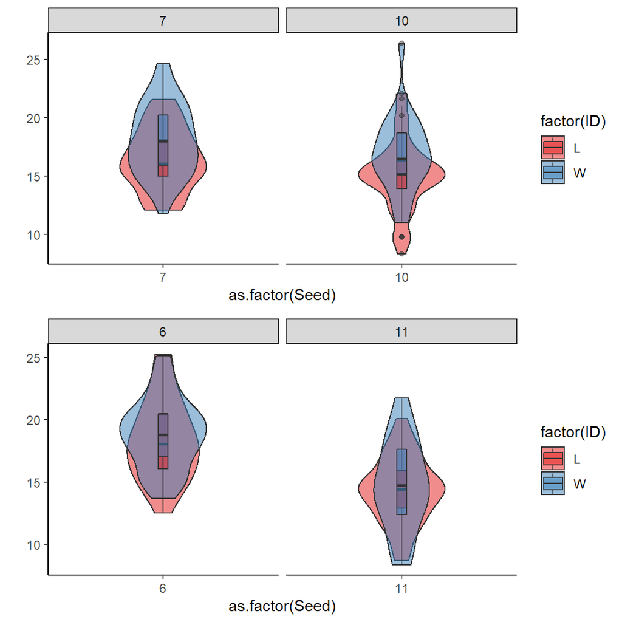

```r
sub = fread("MNCAATourneyCompactResults.csv")
seeds   <- read.csv("NCAATourneySeeds.csv", stringsAsFactors = F)
slots   <- read.csv("NCAATourneySlots.csv", stringsAsFactors = F)
teams   <- read.csv("Teams.csv", stringsAsFactors = F)
names(sub)[3] <- "team1"
names(sub)[5] <- "team2"

SeedRoundSlots <- read.csv("SeedRoundSlots.csv")

colnames(teams)[2] <- "teamName1"
sub <- merge(sub, teams[,c(1,2)], by.x = c("team1"), by.y = c("TeamID"), all.x = T)
colnames(teams)[2] <- "teamName2"
sub <- merge(sub, teams[,c(1,2)], by.x = c("team2"), by.y = c("TeamID"), all.x = T)
# Seeds
colnames(seeds)[2] <- "Seed1"
sub <- merge(sub, seeds, by.x = c("team1", "Season"), by.y = c("TeamID", "Season"), all.x = T)
colnames(seeds)[2] <- "Seed2"
sub <- merge(sub, seeds, by.x = c("team2", "Season"), by.y = c("TeamID", "Season"), all.x = T)

findMatchupRound <- function(seed1, seed2){
  team1Rounds   <- unique(SeedRoundSlots$game_slot[which(SeedRoundSlots$seed == seed1)])
  team2Rounds   <- unique(SeedRoundSlots$game_slot[which(SeedRoundSlots$seed == seed2)])
  intersection  <- team1Rounds[which(team1Rounds %in% team2Rounds)]
  intersectionNum <- SeedRoundSlots$game_round[which(SeedRoundSlots$game_slot %in% intersection)]
  return(min(intersectionNum))
}

sub$round <- NULL
for(i in 1:nrow(sub)){
  sub$round[i] <- findMatchupRound(sub$Seed1[i],sub$Seed2[i])
}

sub$Seed1 = as.numeric(substring(sub$Seed1,2,3))
sub$Seed2 = as.numeric(substring(sub$Seed2,2,3))

sub = sub[,c(2,3,1,11,12,13)]

names(sub)[2] = "TeamID"

finalStats_EM = finalStats[,c("Season","TeamID","EM")]

sub = inner_join(sub,finalStats_EM,c("Season","TeamID"))

names(sub)[3] = "TeamID"
names(sub)[2]<- "Team1"
names(sub)[7] <- "EM_A"


sub = inner_join(sub,finalStats_EM,c("Season","TeamID"))

names(sub)[8] <- "EM_B"

sub$EM = sub$EM_B - sub$EM_A

sub = sub[,c(1,2,3,4,5,6,7,8)]

sub = sub[sub$round == 1 & sub$Seed1 %in% c(6,11),]

sub1 = sub[,c(2,4,7)]

sub2 = sub[,c(3,5,8)]

sub1$ID = rep("W",nrow(sub1))

sub2$ID = rep("L",nrow(sub2))

names(sub1) <- names(sub2) <- c("TeamID","Seed","EM","ID")

sub_EM = rbind(sub1,sub2)

p2=ggplot(data=sub_EM, aes(x=as.factor(Seed),y=EM,fill=factor(ID))) + geom_violin(position = position_dodge(0),alpha=0.5,trim=T) +  geom_boxplot(width = 0.1,position = position_dodge(0),alpha=0.5) +
facet_wrap(~ Seed,scales = "free_x") +   scale_fill_brewer(palette = "Set1") + labs(y="") + theme_bw() + theme(panel.border = element_blank(), panel.grid.major = element_blank(),panel.grid.minor = element_blank(), axis.line = element_line(colour = "black"))

gridExtra::grid.arrange(p1,p2)
```

# 2 Modeling Approach

Now that we have the preliminaries out of the way, the coming sections would focus on predicting the upsets that happen in the first round. However,this approach can be extended to later rounds as well.

## 2.1 Estimation data

I used the tournament data from 2003-2019 for model development. The data was modified such that first team was the underdog. The upset was defined as any team seeded 8 or higher defeats a team that has a lower seed. Based on this definition of upset, there were *303* upsets over the span of 17 years. The offensive and defensive stats along with ordinal ranks were calculated using regular season data.

## 2.2 Variable Selection

Other ways to quantify success of underdogs is by calculating rankings based on how individual team is central are to the whole network. If each node is a division 1 team and they are connected to other teams based on the outcome of head to head games. The weight of each edge depends on the quality of the win, the edge weights were derived using sokols LRMC model. A team that beats other good teams are more central to the network than team with bad losses. A simple way of thinking about this is, each team starts with equal number of quality points, after each game some of the quality point is redistributed to the winning team from the losing team. As the season progresses, the teams with lot of wins will have more quality points thus have a high centrality.

Based on Brenan and Keating’s blog on giant killers, teams that are more chaotic, tends to pull off upsets. The idea being that if a team wins all the games that it is expected to, it would just re-enforce the existing connections. But, if a team pulls off some unexpected wins they would create new edges, thus changing the overall network orientation. Thus centrality measures provide valuable information regarding team quality.

For most of the underdog teams that make a deep run in the tournament, their eigen centrality score is in the top 50. The eigen rank when compared to kenpom ratings for underdog teams that won at least 2 games in the tournament performs well or better in some years seen from the tables below.

```r
tourn=read.csv("MNCAATourneyCompactResults.csv")
teams = read.csv("Teams.csv")
tourney_stats_compact <- tourn %>%
  left_join(teams, by = c("WTeamID" = "TeamID")) %>%
  left_join(teams, by = c("LTeamID" = "TeamID"))

tourney_stats_compact <- tourney_stats_compact %>%
  rename(WTeamName = TeamName.x,
         LTeamName = TeamName.y)

tourney_stats_compact$season_day <- paste(tourney_stats_compact$Season, tourney_stats_compact$DayNum, sep = "_")


# then create a feature to label the round of the tournament
tourney_stats_compact <- tourney_stats_compact %>%
  mutate(TourneyRound = ifelse(DayNum %in% c(134, 135), "Play In",(ifelse(DayNum %in% c(136, 137), "First Round", ifelse(DayNum %in% c(138, 139), "Second Round", ifelse(DayNum %in% c(143, 144), "Sweet 16", ifelse(DayNum %in% c(145, 146), "Elite 8", ifelse(DayNum == 152, "Final Four", "Championship Game")))))))) %>%
  mutate(TourneyRound = factor(TourneyRound, levels = c("First Round", "Second Round", "Sweet 16", "Elite 8", "Final Four", "Championship Game")))
```

```r
EC_N = fread("Eigen_Centrality.csv")
massey_pom_end <-read_csv("MMasseyOrdinals.csv") %>%
  filter(RankingDayNum == max(RankingDayNum)) %>% ungroup() %>% # select the latest date of the season
  filter(SystemName == "POM") %>% # filter out only Pomeroy rankings
  group_by(Season, TeamID) %>%
  filter(RankingDayNum == max(RankingDayNum)) %>% ungroup() %>% # select the latest date of the season
  dplyr::select(Season, TeamID, OrdinalRank)

tourney_seeds = read_csv("NCAATourneySeeds.csv")
tourney_stats_compact %>%
  filter(Season >= 2003) %>%
  left_join(tourney_seeds, by = c("Season", "WTeamID" = "TeamID")) %>%
  left_join(tourney_seeds, by = c("Season", "LTeamID" = "TeamID")) %>%
  rename(WinnerSeed = Seed.x, LoserSeed = Seed.y) %>%
  mutate(WinnerSeed = as.numeric(substring(WinnerSeed,2,3))) %>%
  filter(WinnerSeed > 8) %>%
  left_join(EC_N, by = c("Season", "WTeamID" = "TeamID")) %>%
  filter(TourneyRound %in% c("Sweet 16","Elite 8","Final Four","Championship Game")) %>%
  distinct(Season,WTeamName,Rank_EC) %>%
  dplyr::select(Season,WTeamName, Rank_EC)  %>% head(10) %>% DT::datatable(caption = "Eigen Rank of Teams that won atleast 2 games in the tournament")
```

|  | Season | WTeamName | Rank_EC |
| --- | --- | --- | --- |
| 1 | 2006 | George Mason | 43 |
| 2 | 2008 | Davidson | 65 |
| 3 | 2011 | VA Commonwealth | 52 |
| 4 | 2013 | Wichita St | 27 |
| 5 | 2014 | Dayton | 40 |
| 6 | 2016 | Syracuse | 37 |
| 7 | 2017 | Xavier | 30 |
| 8 | 2018 | Florida St | 50 |
| 9 | 2018 | Kansas St | 37 |
| 10 | 2018 | Loyola-Chicago | 22 |

```r
tourney_seeds = read_csv("NCAATourneySeeds.csv")
 tourney_stats_compact %>%
  filter(Season >= 2003) %>%
  left_join(tourney_seeds, by = c("Season", "WTeamID" = "TeamID")) %>%
  left_join(tourney_seeds, by = c("Season", "LTeamID" = "TeamID")) %>%
  rename(WinnerSeed = Seed.x, LoserSeed = Seed.y) %>%
  mutate(WinnerSeed = as.numeric(substring(WinnerSeed,2,3))) %>%
  filter(WinnerSeed > 8) %>%
  left_join(massey_pom_end, by = c("Season", "WTeamID" = "TeamID")) %>%
  rename(Rank_kp = OrdinalRank) %>%
  filter(TourneyRound %in% c("Sweet 16","Elite 8","Final Four","Championship Game")) %>%
  distinct(Season,WTeamName,Rank_kp) %>%
  dplyr::select(Season,WTeamName, Rank_kp)  %>% head(10) %>% DT::datatable(caption = "Kenpom Rank of Teams that won atleast 2 games in the tournament")
```

|  | Season | WTeamName | Rank_kp |
| --- | --- | --- | --- |
| 1 | 2006 | George Mason | 28 |
| 2 | 2008 | Davidson | 33 |
| 3 | 2011 | VA Commonwealth | 84 |
| 4 | 2013 | Wichita St | 33 |
| 5 | 2014 | Dayton | 51 |
| 6 | 2016 | Syracuse | 41 |
| 7 | 2017 | Xavier | 40 |
| 8 | 2018 | Florida St | 35 |
| 9 | 2018 | Kansas St | 44 |
| 10 | 2018 | Loyola-Chicago | 42 |

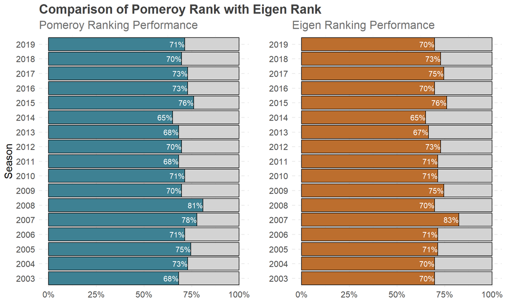

```r
rankings_tourney_analysis_pom <- tourney_stats_compact %>%
  filter(Season >= 2003) %>%
  left_join(massey_pom_end, by = c("Season", "WTeamID" = "TeamID")) %>%
  rename(WinnerRank = OrdinalRank) %>%
  left_join(massey_pom_end, by = c("Season", "LTeamID" = "TeamID")) %>%
  rename(LoserRank = OrdinalRank) %>%
  filter(DayNum >= 136) %>%
  # create a feature that classifies whether the winner was higher or lower ranked
  mutate(WinnerHigher_yes_no = ifelse(WinnerRank < LoserRank, "Winner Ranked Better", "Loser Ranked Better"))


rankings_tourney_summary_pom <- rankings_tourney_analysis_pom %>%
  group_by(Season, WinnerHigher_yes_no) %>%
  summarise(n = n()) %>%
  mutate(prop = round(n / sum(n), 4))



massey_EC_end <- read_csv("Eigen_Centrality.csv") %>% # read in data
  rename(OrdinalRank = Rank_EC ) %>% # select the latest date of the season
  dplyr::select(Season, TeamID, OrdinalRank)



rankings_tourney_analysis_EC <- tourney_stats_compact %>%
  filter(Season >= 2003) %>%
  left_join(massey_EC_end, by = c("Season", "WTeamID" = "TeamID")) %>%
  rename(WinnerRank = OrdinalRank) %>%
  left_join(massey_EC_end, by = c("Season", "LTeamID" = "TeamID")) %>%
  rename(LoserRank = OrdinalRank) %>%
  filter(DayNum >= 136) %>%
  # create a feature that classifies whether the winner was higher or lower ranked
  mutate(WinnerHigher_yes_no = ifelse(WinnerRank < LoserRank, "Winner Ranked Better", "Loser Ranked Better"))


rankings_tourney_summary_EC <- rankings_tourney_analysis_EC %>%
  group_by(Season, WinnerHigher_yes_no) %>%
  summarise(n = n()) %>%
  mutate(prop = round(n / sum(n), 4))


pom <- rankings_tourney_summary_pom %>%
  ggplot(aes(x= factor(Season), y= prop, fill = WinnerHigher_yes_no)) +
  geom_bar(stat = "identity", position = "fill", color = "black") +
  geom_text(data = subset(rankings_tourney_summary_pom, WinnerHigher_yes_no == "Winner Ranked Better"), aes(label = percent(prop)), hjust = 1, colour = "white") +
  scale_fill_manual(values = c("lightgrey", plot_cols[2])) +
  scale_y_continuous(labels = scales::percent) +
  labs(x= "Season") +
  ggtitle("Comparison of Pomeroy Rank with Eigen Rank", subtitle = "Pomeroy Ranking Performance") +
  coord_flip() +
  theme_jason(legend_pos = "none") +
  theme(axis.title.x = element_blank())


sag <- rankings_tourney_summary_EC %>%
  ggplot(aes(x= factor(Season), y= prop, fill = WinnerHigher_yes_no)) +
  geom_bar(stat = "identity", position = "fill", color = "black") +
  geom_text(data = subset(rankings_tourney_summary_EC, WinnerHigher_yes_no == "Winner Ranked Better"), aes(label = percent(prop)), hjust = 1, colour = "white") +
  scale_fill_manual(values = c("lightgrey", plot_cols[3])) +
  scale_y_continuous(labels = scales::percent) +
  labs(x= "") +
  ggtitle("", subtitle = "Eigen Ranking Performance") +
  coord_flip() +
  theme_jason(legend_pos = "none") +
  theme(axis.title.x = element_blank())


grid.arrange(pom, sag, ncol = 2)
```

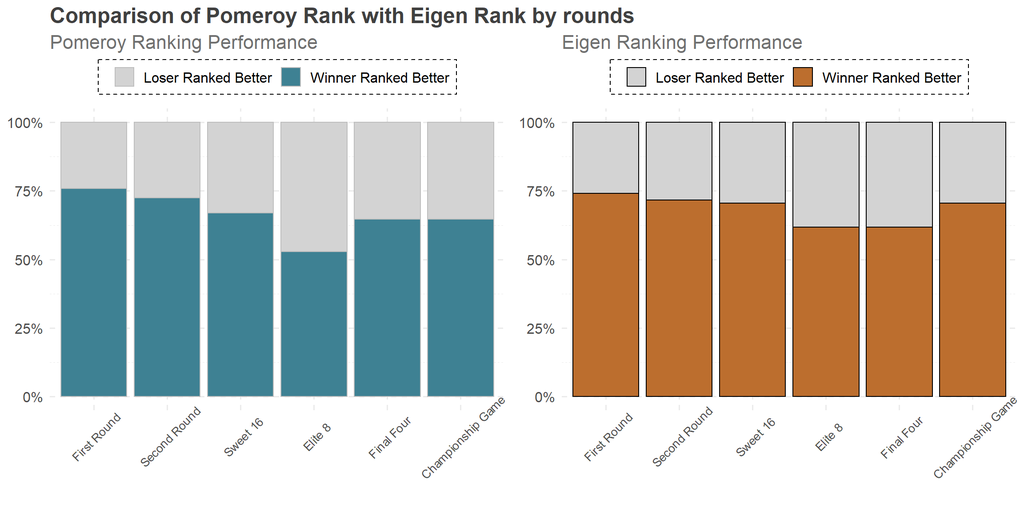

```r
pom <- rankings_tourney_analysis_pom %>%
  ggplot(aes(x= TourneyRound, fill = WinnerHigher_yes_no)) +
  geom_bar(stat = "count", position = "fill", color = "grey") +
  scale_fill_manual(values = c("lightgrey", plot_cols[2])) +
  scale_y_continuous(labels = scales::percent) +
  ggtitle("Comparison of Pomeroy Rank with Eigen Rank by rounds", subtitle = "Pomeroy Ranking Performance") +
  theme_jason() +
  theme(axis.title.x = element_blank(), axis.title.y = element_blank(), axis.text.x = element_text(angle = 45, vjust = .8, size = 10))


sag <- rankings_tourney_analysis_EC %>%
  ggplot(aes(x= TourneyRound, fill = WinnerHigher_yes_no)) +
  geom_bar(stat = "count", position = "fill", color = "black") +
  scale_fill_manual(values = c("lightgrey", plot_cols[3])) +
  scale_y_continuous(labels = scales::percent) +
  ggtitle("", subtitle = "Eigen Ranking Performance") +
  theme_jason() +
  theme(axis.title.x = element_blank(), axis.title.y = element_blank(), axis.text.x = element_text(angle = 45, vjust = .8, size = 10))


grid.arrange(pom, sag, ncol = 2)
```

The goal was to identify what separates the cinderella teams from the rest of the field and how can it be quantified in terms of probability to pulling of an upset. I defined upset as any team seeded 8 or above that defeats a team that is atleast 1 seed lower. The model uses average statistics from regular season games, along with some rankings such as kenpom and other derived ranking based on centrality measures.

## 2.3 The overall modeling approach

1. **A local similarity based approach that calculates a similarity score by comparing each team to past teams that played in the tournament**
2. **A similarity based approach based on the ESPN giant killers blog where high seeded teams are compared to past underdogs that pulled off an upset and lower seeded teams that lost to underdogs**
3. **A global approach based on team wise stats depending on the matchup**

The similarity models uses offensive and defensive statistics as input variables and uses KNN to find the nearest 5 neighbors from teams that have won at least 1 game in the past tournaments starting from 2003. The distance of the neighbors are then aggregated and processed to calculate a composite score. The composite score gives more weight to neighbors that made a deep run in tournament and that have a better ordinal rank. The idea behind this is that a strong neighbor (one with better ordinal rank and deep tournament run in the past) should be more influential than others given that they are close to the current team that. Each year all 68 teams that make into the tournament are compared with the teams from past tournaments and five nearest neighbors are chosen based on Euclidean distance. The input variables are preprocessed by extracting the principal components.

```r
test_dat_final = fread("Input_Data.csv")
finalStats = fread("finaStats.csv")
kp=fread("kenpom_pretourney.csv")
sub = test_dat_final
seeds = fread("NCAATourneySeeds.csv")
slots   <- read.csv("NCAATourneySlots.csv", stringsAsFactors = F)
teams   <- read.csv("Teams.csv", stringsAsFactors = F)
names(sub)[2] <- "team1"
names(sub)[3] <- "team2"
SeedRoundSlots <- read.csv("SeedRoundSlots.csv")

colnames(teams)[2] <- "teamName1"
sub <- merge(sub, teams[,c(1,2)], by.x = c("team1"), by.y = c("TeamID"), all.x = T)
colnames(teams)[2] <- "teamName2"
sub <- merge(sub, teams[,c(1,2)], by.x = c("team2"), by.y = c("TeamID"), all.x = T)
# Seeds
colnames(seeds)[2] <- "Seed1"
sub <- merge(sub, seeds, by.x = c("team1", "Season"), by.y = c("TeamID", "Season"), all.x = T)
colnames(seeds)[2] <- "Seed2"
sub <- merge(sub, seeds, by.x = c("team2", "Season"), by.y = c("TeamID", "Season"), all.x = T)

findMatchupRound <- function(seed1, seed2){
  team1Rounds   <- unique(SeedRoundSlots$game_slot[which(SeedRoundSlots$seed == seed1)])
  team2Rounds   <- unique(SeedRoundSlots$game_slot[which(SeedRoundSlots$seed == seed2)])
  intersection  <- team1Rounds[which(team1Rounds %in% team2Rounds)]
  intersectionNum <- SeedRoundSlots$game_round[which(SeedRoundSlots$game_slot %in% intersection)]
  return(min(intersectionNum))
}


## Distance difference variable
## Add the slot data to the data frame (we need slots so we can add tourneyGeog to this too)
sub$round <- NULL
for(i in 1:nrow(sub)){
  sub$round[i] <- findMatchupRound(sub$Seed1[i],sub$Seed2[i])
}


seeds = fread("NCAATourneySeeds.csv")
test_dat_final = sub[sub$round %in% c(1),]
names(test_dat_final)[1] <- "TeamID"
names(test_dat_final)[3] <- "Team_A"

round_count <- test_dat_final %>% group_by(Team_A,Season) %>% mutate(n=length(Team_A))

test = round_count[round_count$n >= 1 ,]



data = finalStats[,-c(100:102,108)]
finalStats_ = data

clust_mc = fread("Clust_MC.csv")
names(clust_mc)[3] <- "clust_mc"
finalStats_ = inner_join(finalStats_,clust_mc)


upset_teams =which(test_dat_final$Winner == 1)
upset_teams = test_dat_final[upset_teams,c("Season","Team_A")]
names(upset_teams)[2] <- "TeamID"


upset_stats = inner_join(finalStats_,upset_teams)

all_teams1 = test_dat_final[,c("Season","Team_A")]
all_teams2 = test_dat_final[,c("Season","TeamID")]
names(all_teams1)[2] <- "TeamID"
all_teams = rbind(all_teams1,all_teams2)

all_teams = inner_join(finalStats_,all_teams,by=c("Season","TeamID"))


all_teams_stats = all_teams[,names(upset_stats)]

all_teams_stats = inner_join(all_teams_stats,seeds[,c(1,3)],by=c("Season","TeamID"))




non_upset_stats = anti_join(all_teams_stats, upset_stats, by=c("Season","TeamID"))

is.na(upset_stats)<-sapply(upset_stats, is.infinite)
upset_stats[is.na(upset_stats)] <- 0
is.na(non_upset_stats)<-sapply(non_upset_stats, is.infinite)
non_upset_stats[is.na(non_upset_stats)] <- 0
non_upset_stats = inner_join(non_upset_stats,seeds,by=c("Season","TeamID"))
non_upset_stats$Seed = as.numeric(substring(non_upset_stats$Seed,2,3))
non_upset_stats = non_upset_stats[,names(upset_stats)]
upset_stats = upset_stats[!duplicated(upset_stats[c("Season","TeamID")]),]
non_upset_stats = non_upset_stats[!duplicated(non_upset_stats[c("Season","TeamID")]),]
is.na(all_teams_stats)<-sapply(all_teams_stats, is.infinite)
all_teams_stats[is.na(all_teams_stats)] <- 0
all_teams_stats = all_teams_stats[!duplicated(all_teams_stats[c("Season","TeamID")]),]
all_teams_stats = inner_join(all_teams_stats,seeds,by=c("Season","TeamID"))
all_teams_stats$Seed = as.numeric(substring(all_teams_stats$Seed,2,3))

fav_teams_stats = all_teams_stats[all_teams_stats$Seed <= 8,]
fav_teams_stats = fav_teams_stats[,names(upset_stats)]
und_teams_stats = all_teams_stats[all_teams_stats$Seed > 8,]
und_teams_stats = und_teams_stats[,names(upset_stats)]
all_teams_stats = all_teams_stats[,names(upset_stats)]

all_teams_ = finalStats[,c("Season","TeamID")]
all_teams_stats_= inner_join(finalStats_,all_teams_,by=c("Season","TeamID"))
all_teams_stats_ = all_teams_stats_[!duplicated(all_teams_stats_[c("Season","TeamID")]),]
all_teams_stats_ = all_teams_stats_[,names(upset_stats)]
is.na(all_teams_stats_)<-sapply(all_teams_stats_, is.infinite)
all_teams_stats_[is.na(all_teams_stats_)] <- 0


'%notin%' <- Negate("%in%")
simi=list()
exp_ = list()
exp_1 = list()
giant_type = fread("Team_Rounds.csv")
names(giant_type)[1] = "TeamA"
kpd_ = list()
for (i in (2003:2019)){
  kpd = kp[kp$Season == i,]
  kpd$Rank_EM = rank(-kpd$EM,ties.method = "random")
  kpd_[[i]] = kpd
}

kpd_ = do.call(rbind,kpd_)

kpd_ = as.data.frame(kpd_[,c("Season","TeamID","Rank_EM")])
EC = fread("Eigen_Centrality.csv")
ECN = fread("Eigen_Centrality_Nathan.csv")
kpdpe = inner_join(kpd_,EC)
kpdpe = inner_join(kpdpe,ECN)
kpdpe$Rank = round(rowMedians(as.matrix(kpdpe[,c("Rank_EM","Rank_EC","Rank_EC_N")])))
kpdpe = kpdpe[,c("Season","TeamID","Rank")]

fav_teams_stats = fav_teams_stats[,c("DTovP","EP","VarS","TPF","Atov","Rank_EC","p_conf_win","TPD","defense_effective_fg_rat","ASM","FreeThrowsPercent_var","TPS","ORP","Rank_EC_N","Adj_Def","EM","CloseGamesPercent","SPG","SOS","assist_to_fgm_rati","WinsLastSix","Rank_RPI","Away_win_percentage","Hustle","TeamID","Season")]
und_teams_stats = und_teams_stats[,c("DTovP","EP","VarS","TPF","Atov","Rank_EC","p_conf_win","TPD","defense_effective_fg_rat","ASM","FreeThrowsPercent_var","TPS","ORP","Rank_EC_N","Adj_Def","EM","CloseGamesPercent","SPG","SOS","assist_to_fgm_rati","WinsLastSix","Rank_RPI","Away_win_percentage","Hustle","TeamID","Season")]
upset_stats  = upset_stats[,c("DTovP","EP","VarS","TPF","Atov","Rank_EC","p_conf_win","TPD","defense_effective_fg_rat","ASM","FreeThrowsPercent_var","TPS","ORP","Rank_EC_N","Adj_Def","EM","CloseGamesPercent","SPG","SOS","assist_to_fgm_rati","WinsLastSix","Rank_RPI","Away_win_percentage","Hustle","TeamID","Season")]
all_teams_stats =  all_teams_stats[,c("DTovP","EP","VarS","TPF","Atov","Rank_EC","p_conf_win","TPD","defense_effective_fg_rat","ASM","FreeThrowsPercent_var","TPS","ORP","Rank_EC_N","Adj_Def","EM","CloseGamesPercent","SPG","SOS","assist_to_fgm_rati","WinsLastSix","Rank_RPI","Away_win_percentage","Hustle","TeamID","Season")]
round_count = fread("Round_Count.csv")
teams_ = teams[,c(1:2)]
all_teams_stats = inner_join(all_teams_stats,round_count)
all_teams_stats = all_teams_stats[,names(fav_teams_stats)]
giant_type = fread("Cind_Run.csv")

for (i in (2004:2019)){
  tmp1= rbind(all_teams_stats[all_teams_stats$Season < i,])
  tmp2= rbind(und_teams_stats[und_teams_stats$Season == i,],fav_teams_stats[fav_teams_stats$Season == i,])
  up = tmp1 %>% dplyr::select(-c(Season,TeamID))
  noup = tmp2 %>% dplyr::select(-c(Season,TeamID))
  mod1=caret::preProcess(rbind(up,noup),method= c("center", "scale", "nzv"))
  up = BBmisc::normalize(up,)
  noup = BBmisc::normalize(noup)

  pca.norm = prcomp(rbind(up,noup),center = F,scale. = F)
  pca.norm1 = as.matrix(predict(pca.norm,up))
  pca.norm2 = as.matrix(predict(pca.norm,noup))
  mod1 = FNN::knnx.index(pca.norm1[,1:5],pca.norm2[,1:5],k=5)
  mod2 = FNN::knnx.dist(pca.norm1[,1:5],pca.norm2[,1:5],k=5)
  rownames(mod1) <- tmp2$TeamID
  ab=melt(mod1)
  rownames(mod2) <- tmp2$TeamID
  cd=melt(mod2)
  ab$Team_A = tmp1$TeamID[ab$value]
  ab$Season = tmp1$Season[ab$value]
  ab$dist = cd$value
  names(ab)[1] <- "TeamID"
  names(teams_)[1] <- "TeamID"
  teams_ = teams[,c(1:2)]
  ab=inner_join(ab,teams_)
  names(teams_)[1] <- "Team_A"
  names(ab)[7] <- "TeamNameA"
  ab=inner_join(ab,teams_)
  names(ab)[1] <- "Team_C"
  kk = round_count[round_count$Season %notin% i,]

  names(giant_type)[1] = "Team_A"
  names(kpdpe)[2] = "Team_A"
  names(round_count)[2] = "Team_A"
  ab = inner_join(ab,kpdpe,by=c("Season","Team_A"))
  ab = left_join(ab,round_count,by=c("Season","Team_A"))


  ab$comp = ab$dist*ab$Rank/ab$n
  ab = ab[order(ab$comp,decreasing = T),]

  ab= as.data.frame(ab)

  abc = ab %>% group_by(Team_C) %>% summarise(avg_score=weighted.mean(comp,1/Rank,na.rm = T))


  names(abc)[1] <-"TeamID"
  abc = abc[order(abc$avg_score,decreasing = T),]
  abc = inner_join(abc,teams[,1:2])

  exp = data.frame(Season=rep(i,nrow(abc)),TeamID = abc$TeamID, Score = abc$avg_score,Match_team = abc$teamName2)


  match_teams = abc$teamName2


  teamc= abc$TeamID[1:length(match_teams)]

  simi[[i]] = data.frame(Season=rep(i,length(match_teams)),TeamID=teamc, match_teams = match_teams)

  exp_[[i]] <- exp

  exp_1[[i]] = data.frame(Season_ = rep(i,nrow(ab)), ab )
}


res_match = do.call(rbind,simi)

exp = do.call(rbind,exp_)
exp1 = do.call(rbind,exp_1)
```

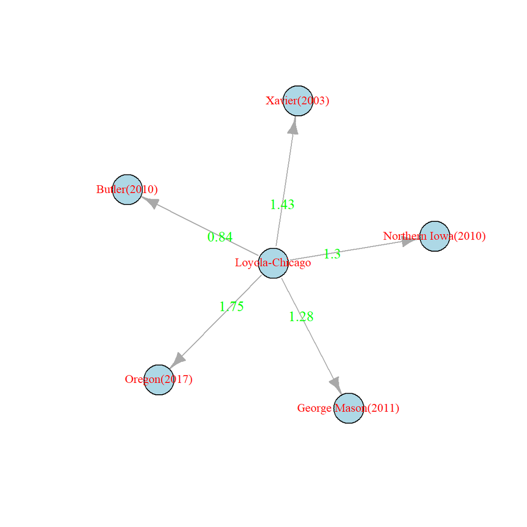

Nearest Neighbor Loyola Chicago (2018).

```r
exp_=exp1[exp1$Season_ == 2018 & exp1$Team_C ==1260,]
exp_$C = paste0(exp_$teamName2,"(",exp_$Season,")")
exp_$U = exp_$TeamNameA
exp_ = exp_[,c("U","C","dist")]
library(igraph)
adj_mat= as.matrix(get.adjacency(graph.data.frame(exp_)))
net2 <- graph_from_adjacency_matrix(adj_mat, mode = "directed", weighted = TRUE)
net2 <- simplify(net2, remove.multiple = F, remove.loops = T)

deg <- degree(net2, mode="all")
V(net2)$size <- deg*3
layout <- layout.reingold.tilford(net2)
plot.igraph(net2,vertex.size=20,vertex.label.cex=.8,vertex.color="lightblue",vertex.label.color = "red",vertex.label.font=1,edge.label = round(exp_$dist,2),edge.label.color="green",layout=layout.fruchterman.reingold(net2, niter=10000))
```

On the other hand, taking a closer look at the University of Miami (FL) team which was the first-round opponent of Loyola Chicago, its nearest neighbors are Gonzaga Bulldogs (2012), Iowa (2015), LSU (2009), Xavier (2010) and Temple (2011). None of the teams except Xavier won more than 1 game, suggesting that the Miami team was a weaker opponent based on its nearest neighbors.

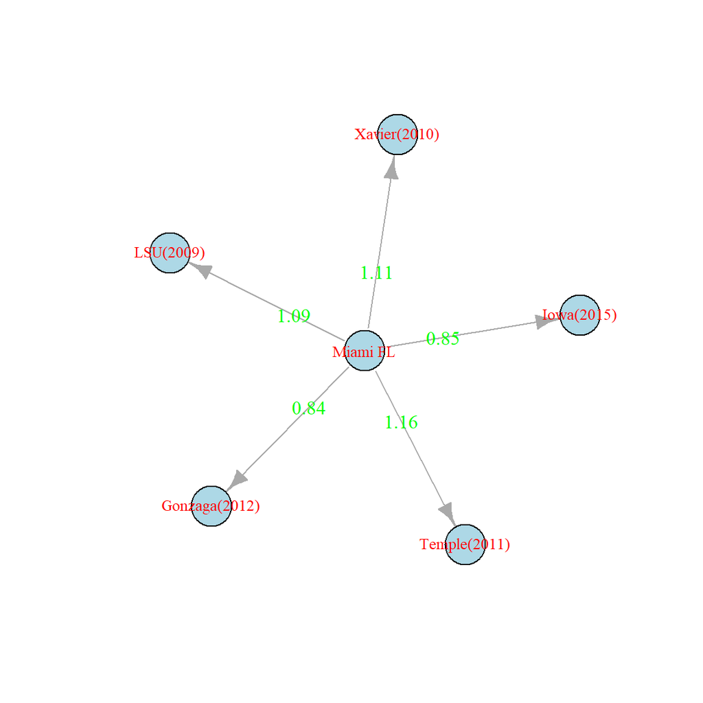

Nearest Neighbor Miami (2018).

```r
exp_=exp1[exp1$Season_ == 2018 & exp1$Team_C ==1274,]
exp_$C = paste0(exp_$teamName2,"(",exp_$Season,")")
exp_$U = exp_$TeamNameA
exp_ = exp_[,c("U","C","dist")]
library(igraph)
adj_mat= as.matrix(get.adjacency(graph.data.frame(exp_)))
net2 <- graph_from_adjacency_matrix(adj_mat, mode = "directed", weighted = TRUE)
net2 <- simplify(net2, remove.multiple = F, remove.loops = T)

deg <- degree(net2, mode="all")
V(net2)$size <- deg*3

layout <- layout.reingold.tilford(net2)
plot.igraph(net2,vertex.size=20,vertex.label.cex=.8,vertex.color="lightblue",vertex.label.color = "red",vertex.label.font=1,edge.label = round(exp_$dist,2),edge.label.color="green",layout=layout.fruchterman.reingold(net2, niter=10000))
```

One of the unlikeliest upsets happened in 2018, where a 16th seed defeated the 1st seed. Looking at the nearest neighbors of UMBC, it closely resembles the 2011 VCU team, the team was a 11 seeded team, that defeated the number 1 seed Kansas Jayhawks on their way to the final four.

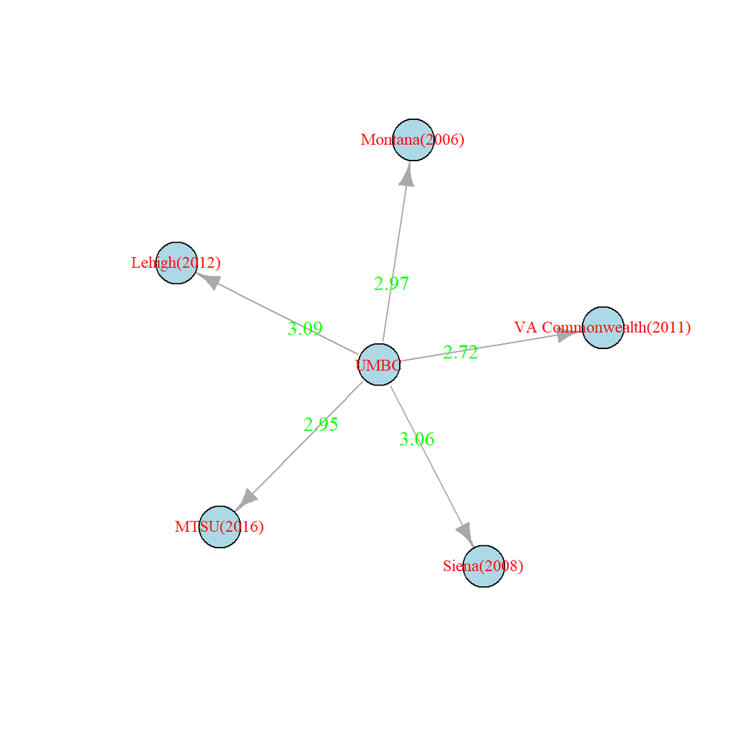

Nearest Neighbor UMBC (2018).

```r
exp_=exp1[exp1$Season_ == 2018 & exp1$Team_C ==1420,]
exp_$C = paste0(exp_$teamName2,"(",exp_$Season,")")
exp_$U = exp_$TeamNameA
exp_ = exp_[,c("U","C","dist")]
library(igraph)
adj_mat= as.matrix(get.adjacency(graph.data.frame(exp_)))
net2 <- graph_from_adjacency_matrix(adj_mat, mode = "directed", weighted = TRUE)
net2 <- simplify(net2, remove.multiple = F, remove.loops = T)

deg <- degree(net2, mode="all")
V(net2)$size <- deg*3

layout <- layout.reingold.tilford(net2)
plot.igraph(net2,vertex.size=20,vertex.label.cex=.8,vertex.color="lightblue",vertex.label.color = "red",vertex.label.font=1,edge.label = round(exp_$dist,2),edge.label.color="green",layout=layout.fruchterman.reingold(net2, niter=10000))
```

All these results suggest that instead of using raw statistics, smilarity measures based on these statsitcs can be more effective in identifyting potential upsets for a given match-up.

The results from the second similarity based approach based on the ESPN giant killers blog follows a similar approach as the first one except that in this approach lower seeded teams are compared to past underdogs who pulled off upsets and the higher seeded teams that lost to underdogs. ESPN looks for potential upsets by looking for teams that are stronger than their seed would suggest or by finding match-ups where the weaker seeded team has a strength that could exploit the weakness of a stronger team (Brenner and Keating 2015; Dutta, 2017).

ESPN defines four subgroups of favourite teams that are susceptible to upset:

1. Power giants: Crash the offensive board, decent defensive rebounders and do not force many turnovers
2. Gambling giants: Crash the offensive board, weak defensive rebounding, force many turnovers
3. Pack-line giants: Average offensive rebounding, do not force many turnovers, good defensive rebounding
4. Generic giants: Generally skilled, not specifically strong in offensive rebounding or generating turnovers

ESPN also defines four categories of low seed teams that have the potential to upset:  
1. Generic killers: Decent teams with no especially strong rebounding, turnovers, shooting, or defense 2. Slow killers: Strong offensive rebounding, limit opponent shooting, neither generate steals nor shoot 3-point shots 3. Perimeter killers: Strong 3-point shooters, generate lots of steals, weak offensive rebounding, weak at limiting opponent shooting 4. High-possession killers: Limit opponent shot accuracy, strong offensive rebounding, do not shoot many 3-point shots

These categories are then analyzed to see which Giants (high seed teams) could fall to which Giant killers (low seed teams). ESPN’s conclusions are shown in figure below, where an arrow from a Giant to a Giant killer means that the Giant is weak against that Giant killer and an arrow from a Giant killer to a Giant means that the Giant killer is strong against that Giant.

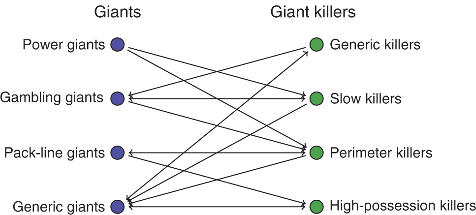

Giant Killers

```r
knitr::include_graphics("Giant_Killers.jpg")
```

Although the extact methodology for grouping identifying categories under giants and killers is not clear, I used a clustering based approach to gruoup underdogs and favourites into four subgroups based on their offensive and defensive stats. The resulting subgroups for the giants and killers are shown in the table below./ Based on the graphic above, pack line giants are suseptible to upset by high possession killers. In 2018 UVA was a packline giant and UMBC was a high posession killer, these results provide additional validation to the results published by the ESPN blog.

```r
type = fread("Giant_Killer.csv")
teams=fread("Teams.csv")
giant_analysis <- fread("MNCAATourneyCompactResults.csv") %>%
  filter(Season >= 2003) %>%
   filter(DayNum <= 138) %>%
  left_join(type, by = c("Season", "WTeamID" = "TeamID")) %>%
  rename(Winning_Team_Type= Type) %>%
  left_join(type, by = c("Season", "LTeamID" = "TeamID")) %>%
  rename(Losing_Team_Type = Type)%>%
  left_join(tourney_seeds, by = c("Season", "WTeamID" = "TeamID")) %>%
  left_join(tourney_seeds, by = c("Season", "LTeamID" = "TeamID")) %>%
  rename(WinnerSeed = Seed.x, LoserSeed = Seed.y) %>%
  mutate(WinnerSeed = as.numeric(substring(WinnerSeed,2,3))) %>%
  mutate(LoserSeed = as.numeric(substring(LoserSeed,2,3))) %>%
  mutate(Seed_Diff = WinnerSeed - LoserSeed) %>%
  filter(Seed_Diff >= 4) %>%
  filter(Season >= 2018) %>%
  left_join(teams[,1:2], by = c("WTeamID" = "TeamID")) %>%
  left_join(teams[,1:2], by = c("LTeamID" = "TeamID")) %>%
  rename(Winning_Team = TeamName.x, Losing_Team = TeamName.y)
giant_analysis[,c(1,9,10,14,15)] %>% head(10) %>% DT::datatable(caption = "List of type of Giant Killers that pulled off upsets in 2018 ans 2019")
```

|  | Season | Winning_Team_Type | Losing_Team_Type | Winning_Team | Losing_Team |
| --- | --- | --- | --- | --- | --- |
| 1 | 2018 | High Posss Killer | Generic Giant | Buffalo | Arizona |
| 2 | 2018 | Slow Killers | Pack-line giants | Loyola-Chicago | Miami FL |
| 3 | 2018 | Perimeter Killers | Generic Giant | Marshall | Wichita St |
| 4 | 2018 | High Posss Killer | Power Giants | Syracuse | TCU |
| 5 | 2018 | High Posss Killer | Pack-line giants | UMBC | Virginia |
| 6 | 2018 | Slow Killers | Pack-line giants | Loyola-Chicago | Tennessee |
| 7 | 2019 | Slow Killers | Pack-line giants | Murray St | Marquette |
| 8 | 2019 | High Posss Killer | Gambling giants | Liberty | Mississippi St |
| 9 | 2019 | Generic Killers | Power Giants | Ohio St | Iowa St |
| 10 | 2019 | Perimeter Killers | Pack-line giants | Oregon | Wisconsin |

```r
test_dat_final = fread("Input_Data.csv")
sub = test_dat_final
seeds = fread("NCAATourneySeeds.csv")
seeds   <- read.csv("NCAATourneySeeds.csv", stringsAsFactors = F)
slots   <- read.csv("NCAATourneySlots.csv", stringsAsFactors = F)
teams   <- read.csv("Teams.csv", stringsAsFactors = F)#read.csv("Sub_2014_2018.csv")
names(sub)[2] <- "team1"
names(sub)[3] <- "team2"
#sub <- read.csv("Test_Bounds.csv")
SeedRoundSlots <- read.csv("SeedRoundSlots.csv")
#sub$Season <- as.numeric(substr(sub$ID, 1, 4))
#sub$team1  <- as.numeric(substr(sub$ID, 6, 9))
#sub$team2  <- as.numeric(substr(sub$ID, 11, 14))

colnames(teams)[2] <- "teamName1"
sub <- merge(sub, teams[,c(1,2)], by.x = c("team1"), by.y = c("TeamID"), all.x = T)
colnames(teams)[2] <- "teamName2"
sub <- merge(sub, teams[,c(1,2)], by.x = c("team2"), by.y = c("TeamID"), all.x = T)
# Seeds
colnames(seeds)[2] <- "Seed1"
sub <- merge(sub, seeds, by.x = c("team1", "Season"), by.y = c("TeamID", "Season"), all.x = T)
colnames(seeds)[2] <- "Seed2"
sub <- merge(sub, seeds, by.x = c("team2", "Season"), by.y = c("TeamID", "Season"), all.x = T)

findMatchupRound <- function(seed1, seed2){
  team1Rounds   <- unique(SeedRoundSlots$game_slot[which(SeedRoundSlots$seed == seed1)])
  team2Rounds   <- unique(SeedRoundSlots$game_slot[which(SeedRoundSlots$seed == seed2)])
  intersection  <- team1Rounds[which(team1Rounds %in% team2Rounds)]
  intersectionNum <- SeedRoundSlots$game_round[which(SeedRoundSlots$game_slot %in% intersection)]
  return(min(intersectionNum))
}


## Distance difference variable
## Add the slot data to the data frame (we need slots so we can add tourneyGeog to this too)
sub$round <- NULL
for(i in 1:nrow(sub)){
  sub$round[i] <- findMatchupRound(sub$Seed1[i],sub$Seed2[i])
}


seeds = fread("NCAATourneySeeds.csv")
test_dat_final = sub[sub$round %in% c(1),]
#test_dat_final <- test_dat_final[as.numeric(substring(test_dat_final$Seed1,2,3)) > 9,]
names(test_dat_final)[1] <- "TeamID"
names(test_dat_final)[3] <- "Team_A"

round_count <- test_dat_final %>% group_by(Team_A,Season) %>% mutate(n=length(Team_A))

test = round_count[round_count$n >= 1 ,]



#data = #finalStats[,c(1:86,94:97,99,101,103,106,116:158,175:197,202:245,247:266)]
data = finalStats[,-c(98:101,108)]
#clust_mc$clust = as.numeric(clust_mc$clust)

#data = inner_join(data,clust_mc)

finalStats_ = data#dplyr::select(finalStats,c(Season,TeamID,ends_with("_Z"),clust))

finalStats_ = inner_join(finalStats_,seeds)
finalStats_$Seed = substring(finalStats_$Seed,1,3)


clust_mc = fread("Clust_MC.csv")
names(clust_mc)[3] <- "clust_mc"
finalStats_ = inner_join(finalStats_,clust_mc)


killer_teams =which(test_dat_final$Winner == 1)
killer_teams = test_dat_final[killer_teams,c("Season","Team_A")]
names(killer_teams)[2] <- "TeamID"


giant_teams =which(test_dat_final$Winner == 1)
giant_teams = test_dat_final[giant_teams,c("Season","TeamID")]
names(giant_teams)[2] <- "TeamID"

killer_stats = inner_join(finalStats_,killer_teams)
#killer_stats = inner_join(killer_stats,seeds)
giant_stats = inner_join(finalStats_,giant_teams)
#giant_stats = inner_join(giant_stats,seeds)

all_teams1 = test_dat_final[,c("Season","Team_A")]
all_teams2 = test_dat_final[,c("Season","TeamID")]
names(all_teams1)[2] <- "TeamID"
all_teams1 = inner_join(finalStats_,all_teams1,by=c("Season","TeamID"))
all_teams2 = inner_join(finalStats_,all_teams2,by=c("Season","TeamID"))


is.na(killer_stats)<-sapply(killer_stats, is.infinite)
killer_stats[is.na(killer_stats)] <- 0
is.na(giant_stats)<-sapply(giant_stats, is.infinite)
giant_stats[is.na(giant_stats)] <- 0

#fav_teams_stats = all_teams_stats[all_teams_stats$Seed < 8,]
#fav_teams_stats = fav_teams_stats[,names(giant_stats)]
#und_teams_stats = all_teams_stats[all_teams_stats$Seed >= 8,]
#und_teams_stats = und_teams_stats[,names(killer_stats)]
fav_teams_stats = all_teams2[,names(giant_stats)]
und_teams_stats = all_teams1[,names(killer_stats)]
giant_type=fread("Giant_Killer.csv")

'%notin%' <- Negate("%in%")
simi=list()
exp_ = list()
exp_1 = list()
giant_type = fread("Team_Rounds.csv")
names(giant_type)[1] = "TeamA"
kpd_ = list()
for (i in (2003:2019)){
  kpd = kp[kp$Season == i,]
  kpd$Rank_EM = rank(-kpd$EM,ties.method = "random")
  kpd_[[i]] = kpd
}

kpd_ = do.call(rbind,kpd_)

kpd_ = as.data.frame(kpd_[,c("Season","TeamID","Rank_EM")])
EC = fread("Eigen_Centrality.csv")
ECN = fread("Eigen_Centrality_Nathan.csv")
kpdpe = inner_join(kpd_,EC)
kpdpe = inner_join(kpdpe,ECN)
kpdpe$Rank = round(rowMedians(as.matrix(kpdpe[,c("Rank_EM","Rank_EC","Rank_EC_N")])))
kpdpe = kpdpe[,c("Season","TeamID","Rank")]
#upset_stats = dplyr::select(upset_stats,-ends_with("_Z"),TeamID,Season)
#all_teams_stats = dplyr::select(all_teams_stats,-ends_with("_Z"),TeamID,Season)
#upset_stats = dplyr::select(upset_stats,APG,SPG,Adj_Off,Adj_Def,ORP, DRP, EM,EP,Atov,Hustle,Four_Fac_D,adj_tempo,PIE,VarS,Stov,O,D,TeamID,Season)
#all_teams_stats = dplyr::select(all_teams_stats,APG,SPG,Adj_Off,Adj_Def,ORP, DRP, EM,EP,Atov,Hustle,Four_Fac_D,adj_tempo,PIE,VarS,Stov,O,D,TeamID,Season)
killer_stats  = dplyr::select(killer_stats,APG,SPG,ORP,DRP,EP,TPF,TPS,TovD,defense_effective_fg_rat,SOS,Adj_Off,Adj_Def,Type,Seed,TeamID,Season)
und_teams_stats = dplyr::select(und_teams_stats,APG,SPG,ORP,DRP,EP,TPF,TPS,TovD,defense_effective_fg_rat,SOS,Adj_Off,Adj_Def,Type,Seed,TeamID,Season)

round_count = fread("Round_Count.csv")
giant_type=fread("Giant_Killer.csv")
giant_type$n = ifelse(giant_type$Type %in% c("Power Giants","High Posss Killer"),5,ifelse(giant_type$Type %in% c("Gambling giants","Perimeter Killers"),4,ifelse(giant_type$Type %in% c("Pack-line giants","Slow Killers"),3,2)))

for (i in (2004:2019)){
  tmp1= rbind(killer_stats[killer_stats$Season < i,])#,fav_teams_stats[fav_teams_stats$Season == i,])#,upset_stats[upset_stats$Season < i,])
  tmp2=und_teams_stats[und_teams_stats$Season == i,]#sund_teams_stats[und_teams_stats$Season==i,]#rbind(non_upset_stats[non_upset_stats$Season == i,])#[upset_stats$Season == i,])
  up = tmp1 %>% dplyr::select(-c(Season,TeamID,Seed))
  noup = tmp2 %>% dplyr::select(-c(Season,TeamID,Seed))
  mod1=caret::preProcess(rbind(up,noup),method= c("center", "scale", "nzv"))
  up = BBmisc::normalize(up,)#mpredict(mod1,up)
  noup = BBmisc::normalize(noup)
  #up=rowSums(up)
  #noup  = rowSums(noup)
  pca.norm = prcomp(rbind(up,noup),center = F,scale. = F)
  pca.norm1 = as.matrix(predict(pca.norm,up))
  pca.norm2 = as.matrix(predict(pca.norm,noup))
```

```r
  #mnist_train_umap <- uwot::umap(rbind(pca.norm1,pca.norm1), verbose = F, ret_model = TRUE)
  #mnist_test_up <- uwot::umap_transform(pca.norm1, mnist_train_umap, verbose = F)
  #mnist_test_noup <- uwot::umap_transform(pca.norm2, mnist_train_umap, verbose = F)
  #tsne.norm1 = Rtsne(pca.norm1,check_duplicates = F,perplexity = 5)
  #tsne.norm2 = Rtsne(pca.norm2,check_duplicates = F,perplexity = 5)
  mod1 = FNN::knnx.index(pca.norm1[,1:5],pca.norm2[,1:5],k=5)
  mod2 = FNN::knnx.dist(pca.norm1[,1:5],pca.norm2[,1:5],k=5)
   #mod1=rnn$nn.idx
  #mod2 = rnn$nn.dists
  rownames(mod1) <- tmp2$TeamID
  ab=melt(mod1)
  rownames(mod2) <- tmp2$TeamID
  cd=melt(mod2)
  ab$Team_A = tmp1$TeamID[ab$value]
  ab$Season = tmp1$Season[ab$value]
  ab$dist = cd$value
  names(ab)[1] <- "TeamID"
  names(teams_)[1] <- "TeamID"
  teams_ = teams[,c(1:2)]
  ab=inner_join(ab,teams_)
  names(teams_)[1] <- "Team_A"
  names(ab)[7] <- "TeamNameA"
  ab=inner_join(ab,teams_)
  names(ab)[1] <- "Team_C"
  seed_ = tmp1$Seed[ab$value]

  temp=c()
  k=1
  while(k <= length(seed_)){
    j=which(slots$Season == ab$Season[k] & slots$WeakSeed == seed_[k])
    temp[k] = slots$StrongSeed[j]
    k=k+1
}

  ab$Seed = as.numeric(substring(temp,2,3))
  names(giant_type)[2] <- "Team_A"
  ab = inner_join(ab,giant_type,by=c("Season","Team_A"))
  ab$comp = ab$dist*ab$Seed/ab$n #aifelse(ab$Type_Giant == "Cinderella", ab$dist/4, ifelse(ab$Type_Giant == "Killers",ab$dist/2,ab$dist))


  ab = ab[order(ab$comp,decreasing = T),]

  ab= as.data.frame(ab)

  abc = ab %>% group_by(Team_C) %>% summarise(avg_score=weighted.mean(comp,1/Seed,na.rm = T))#,n_ = mean(n))



  #abc$avg_score = ifelse(abc$n_ > 3, abc$avg_score/5,abc$avg_score)
  names(abc)[1] <-"TeamID"
  abc = abc[order(abc$avg_score,decreasing = T),]
  abc = inner_join(abc,teams[,1:2])

  exp = data.frame(Season=rep(i,nrow(abc)),TeamID = abc$TeamID, Score = abc$avg_score,Match_team = abc$teamName2)


  match_teams = abc$teamName2


  teamc= abc$TeamID[1:length(match_teams)]


  simi[[i]] = data.frame(Season=rep(i,length(match_teams)),TeamID=teamc, match_teams = match_teams)

  exp_[[i]] <- exp

  exp_1[[i]] = data.frame(Season_ = rep(i,nrow(ab)), ab )
}


res_match = do.call(rbind,simi)

exp = do.call(rbind,exp_)
exp1 = do.call(rbind,exp_1)

giant_stats = dplyr::select(giant_stats,APG,SPG,ORP,DRP,TPF,TPS,TovD,Adj_Off,Adj_Def,Type,Seed,TeamID,Season)
fav_teams_stats = dplyr::select(fav_teams_stats,APG,SPG,ORP,DRP,TPF,TPS,TovD,Adj_Off,Adj_Def,Type,Seed,TeamID,Season)


'%notin%' <- Negate("%in%")
simi=list()
exp_ = list()
exp_2 = list()


for (i in (2004:2019)){
  tmp1= rbind(giant_stats[giant_stats$Season < i,])#,fav_teams_stats[fav_teams_stats$Season == i,])#,upset_stats[upset_stats$Season < i,])
  tmp2=fav_teams_stats[fav_teams_stats$Season == i,]#sund_teams_stats[und_teams_stats$Season==i,]#rbind(non_upset_stats[non_upset_stats$Season == i,])#[upset_stats$Season == i,])
  up = tmp1 %>% dplyr::select(-c(Season,TeamID,Seed))
  noup = tmp2 %>% dplyr::select(-c(Season,TeamID,Seed))
  mod1=caret::preProcess(rbind(up,noup),method= c("center", "scale", "nzv"))
  up = BBmisc::normalize(up,)#mpredict(mod1,up)
  noup = BBmisc::normalize(noup)
  #up=rowSums(up)
  #noup  = rowSums(noup)
  pca.norm = prcomp(rbind(up,noup),center = F,scale. = F)
  pca.norm1 = as.matrix(predict(pca.norm,up))
  pca.norm2 = as.matrix(predict(pca.norm,noup))

  #mnist_train_umap <- uwot::umap(rbind(pca.norm1,pca.norm1), verbose = F, ret_model = TRUE)
  #mnist_test_up <- uwot::umap_transform(pca.norm1, mnist_train_umap, verbose = F)
  #mnist_test_noup <- uwot::umap_transform(pca.norm2, mnist_train_umap, verbose = F)
  #tsne.norm1 = Rtsne(pca.norm1,check_duplicates = F,perplexity = 5)
  #tsne.norm2 = Rtsne(pca.norm2,check_duplicates = F,perplexity = 5)
  mod1 = FNN::knnx.index(pca.norm1[,1:5],pca.norm2[,1:5],k=5)
  mod2 = FNN::knnx.dist(pca.norm1[,1:5],pca.norm2[,1:5],k=5)
  #mod1=rnn$nn.idx
  #mod2 = rnn$nn.dists
  rownames(mod1) <- tmp2$TeamID
  ab=melt(mod1)
  rownames(mod2) <- tmp2$TeamID
  cd=melt(mod2)
  ab$Team_A = tmp1$TeamID[ab$value]
  ab$Season = tmp1$Season[ab$value]
  ab$dist = cd$value
  names(ab)[1] <- "TeamID"
  names(teams_)[1] <- "TeamID"
  teams_ = teams[,c(1:2)]
  ab=inner_join(ab,teams_)
  names(teams_)[1] <- "Team_A"
  names(ab)[7] <- "TeamNameA"
  ab=inner_join(ab,teams_)
  names(ab)[1] <- "Team_C"
  seed_ = tmp1$Seed[ab$value]

  temp=c()
  k=1
  while(k <= length(seed_)){
    j=which(slots$Season == ab$Season[k] & slots$StrongSeed == seed_[k])
    temp[k] = slots$WeakSeed[j]
    k=k+1
  }

  ab$Seed = as.numeric(substring(temp,2,3))
  names(giant_type)[2] <- "Team_A"
  ab = inner_join(ab,giant_type,by=c("Season","Team_A"))
  ab$comp = ab$dist*ab$Seed/ab$n #aifelse(ab$Type_Giant == "Cinderella", ab$dist/4, ifelse(ab$Type_Giant == "Killers",ab$dist/2,ab$dist))
  ab = ab[order(ab$comp,decreasing = T),]
  ab= as.data.frame(ab)
  abc = ab %>% group_by(Team_C) %>% summarise(avg_score=weighted.mean(comp,1/Seed,na.rm = T))#,n_ = mean(n))



  #abc$avg_score = ifelse(abc$n_ > 3, abc$avg_score/5,abc$avg_score)
  names(abc)[1] <-"TeamID"
  abc = abc[order(abc$avg_score,decreasing = T),]
  abc = inner_join(abc,teams[,1:2])

  exp_1 = data.frame(Season=rep(i,nrow(abc)),TeamID = abc$TeamID, Score = abc$avg_score,Match_team = abc$teamName2)


  match_teams = abc$teamName2


  teamc= abc$TeamID[1:length(match_teams)]


  simi[[i]] = data.frame(Season=rep(i,length(match_teams)),TeamID=teamc, match_teams = match_teams)

  exp_[[i]] <- exp_1

  exp_2[[i]] = data.frame(Season_ = rep(i,nrow(ab)), ab )
}


res_match = do.call(rbind,simi)

exp_1 = do.call(rbind,exp_)
exp1_ = do.call(rbind,exp_2)
```

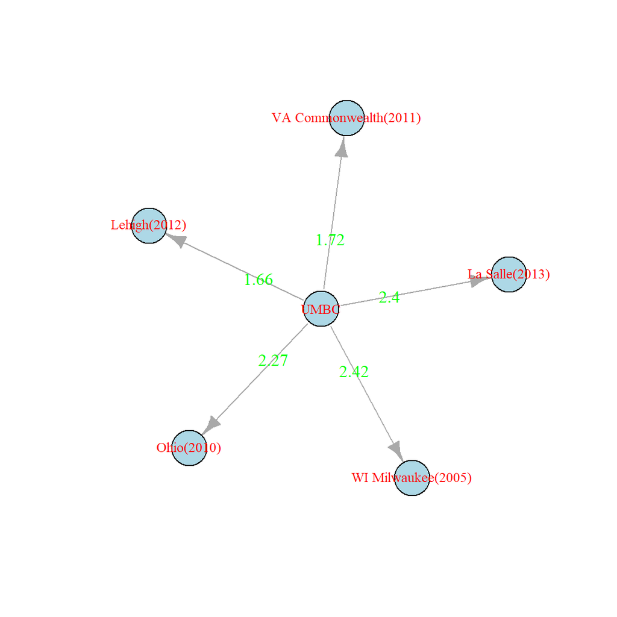

Nearest Neighbor UMBC (2018).

```r
exp_=exp1[exp1$Season_ == 2018 & exp1$Team_C ==1420,]
exp_$C = paste0(exp_$teamName2,"(",exp_$Season,")")
exp_$U = exp_$TeamNameA
exp_ = exp_[,c("U","C","dist")]
library(igraph)
adj_mat= as.matrix(get.adjacency(graph.data.frame(exp_)))
net2 <- graph_from_adjacency_matrix(adj_mat, mode = "directed", weighted = TRUE)
net2 <- simplify(net2, remove.multiple = F, remove.loops = T)

deg <- degree(net2, mode="all")
V(net2)$size <- deg*3

layout <- layout.reingold.tilford(net2)
plot.igraph(net2,vertex.size=20,vertex.label.cex=.8,vertex.color="lightblue",vertex.label.color = "red",vertex.label.font=1,edge.label = round(exp_$dist,2),edge.label.color="green",layout=layout.fruchterman.reingold(net2, niter=10000))
```

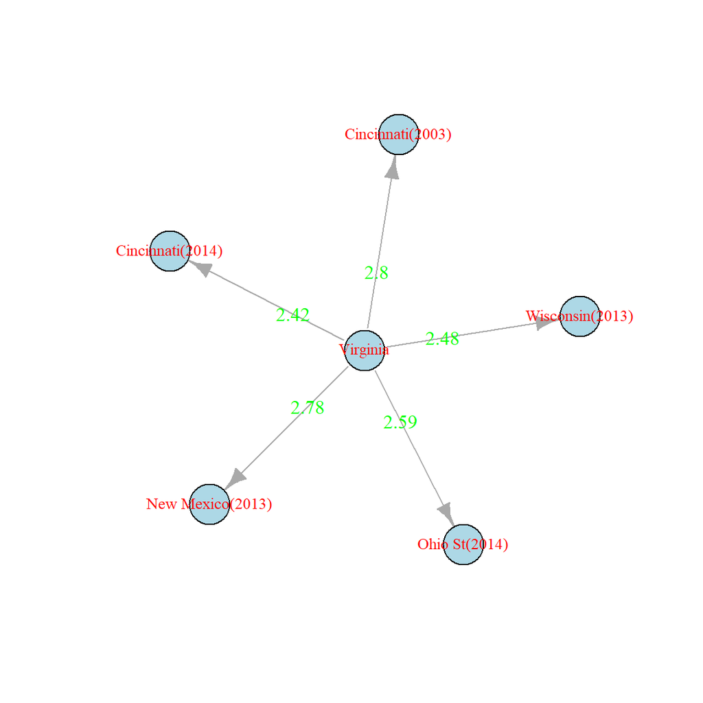

Nearest Neighbor UVA (2018).

```r
exp_=exp1_[exp1_$Season_ == 2018 & exp1_$Team_C ==1438,]
exp_$C = paste0(exp_$teamName2,"(",exp_$Season,")")
exp_$U = exp_$TeamNameA
exp_ = exp_[,c("U","C","dist")]
library(igraph)
adj_mat= as.matrix(get.adjacency(graph.data.frame(exp_)))
net2 <- graph_from_adjacency_matrix(adj_mat, mode = "directed", weighted = TRUE)
net2 <- simplify(net2, remove.multiple = F, remove.loops = T)

deg <- degree(net2, mode="all")
V(net2)$size <- deg*3

layout <- layout.reingold.tilford(net2)
plot.igraph(net2,vertex.size=20,vertex.label.cex=.8,vertex.color="lightblue",vertex.label.color = "red",vertex.label.font=1,edge.label = round(exp_$dist,2),edge.label.color="green",layout=layout.fruchterman.reingold(net2, niter=10000))
```

The advantages of a similarity-based approach is that it tries to extract information in a small region without generalization. This approach tries to answer given that a higher seeded team is similar to the teams in the past that made a deep run in the NCAA tournament, how likely are they to win compared to other teams that don’t resemble cinderella teams? The similarity-based measures are them mapped to probabilities of upset by using a logistic regression.

The final model is a combination of 3 models, 2 based on similarity scores and the third is a simple logistic regression based on season long offensive and defensive statistics. The variables used for the third model belong to the following groups 1) Rebounds 2) Efficiency and 4) Possessions. Each of the variables were chosen based on the current literature as well as wells as cross-validation. The plots of some of the variables are shown in the plots below.

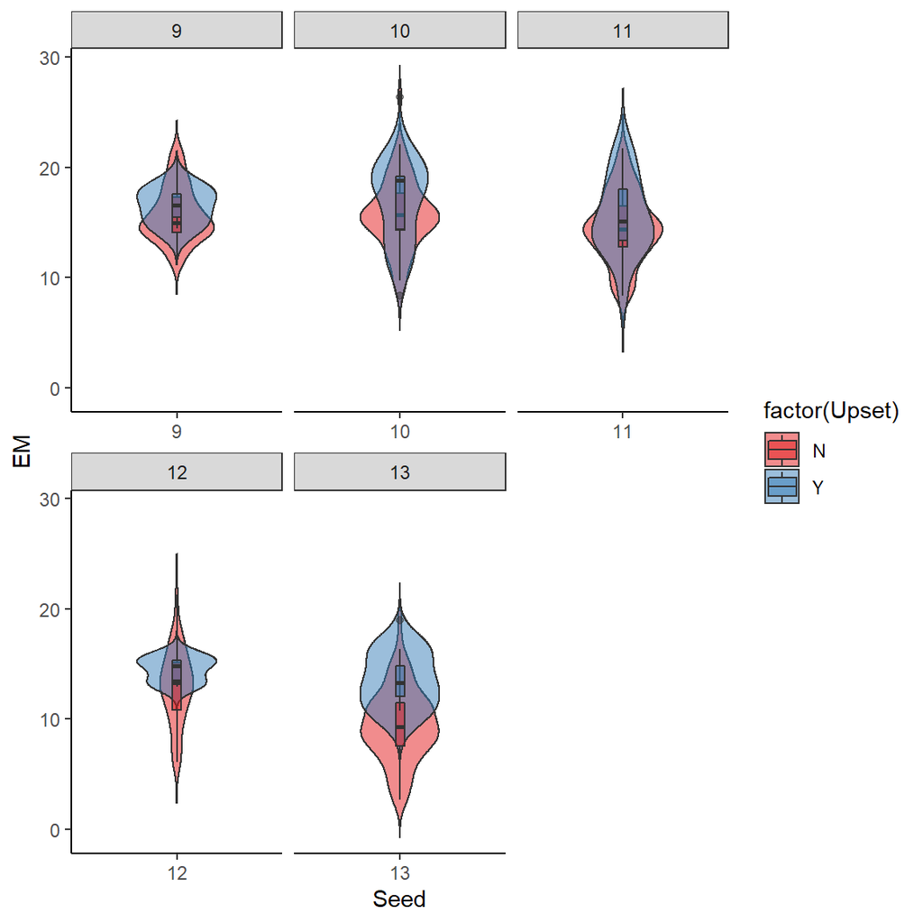

```r
test_dat_final = fread("Input_Data.csv")
plot_func=function(x){
fstats_TovD = dplyr::select(finalStats,Season,TeamID,Seed,x)
upset_teams  = test_dat_final[test_dat_final$Winner == 0,]
upset_teams = upset_teams [,c("Season","UTeamID")]
names(upset_teams)[2] <- "TeamID"
fstats_TovD = inner_join(upset_teams,fstats_TovD,by=c("Season","TeamID"))
fstats_TovD = fstats_TovD[fstats_TovD$Seed > 8,]
round_count_=round_count[round_count$n >= 2,]
names(round_count_)[2] <- "TeamID"
fstats_TovD = inner_join(fstats_TovD,round_count_,by = c("Season", "TeamID"))
fstats_TovD = fstats_TovD[fstats_TovD$Seed %in% c(9,10,11,12,13),]
fstats_TovD = fstats_TovD[,1:4]
fstats_TovD$Upset = rep("Y",nrow(fstats_TovD))
fstats_TovD_ = dplyr::select(finalStats,Season,TeamID,Seed,x)
non_up = test_dat_final[test_dat_final$Winner == 0,]
non_up = non_up[,c("Season","UTeamID")]
names(non_up)[2] <- "TeamID"
fstats_TovD_non = inner_join(fstats_TovD_,non_up,by=c("Season","TeamID"))
fstats_TovD_non = fstats_TovD_non[fstats_TovD_non$Seed > 8,]
fstats_TovD_non = fstats_TovD_non[complete.cases(fstats_TovD_non),]
fstats_TovD_non = fstats_TovD_non[fstats_TovD_non$Seed %in% c(9,10,11,12,13),]
fstats_TovD_non$Upset = rep("N",nrow(fstats_TovD_non))

fstats_TovD = rbind(fstats_TovD,fstats_TovD_non)

x1=sym(x)
p1=ggplot(data=fstats_TovD, aes(x=as.factor(Seed),y= !! x1,fill=factor(Upset))) + geom_violin(position = position_dodge(0),alpha=0.5,trim=F) + geom_boxplot(width = 0.1,position = position_dodge(0),alpha=0.5)+ facet_wrap(~ Seed,scales = "free_x") +   scale_fill_brewer(palette = "Set1") + labs(y=x,x="Seed")  +  theme_bw() + theme(panel.border = element_blank(), panel.grid.major = element_blank(),panel.grid.minor = element_blank(), axis.line = element_line(colour = "black"))

print(p1)}
plot_func(x="EM")
```

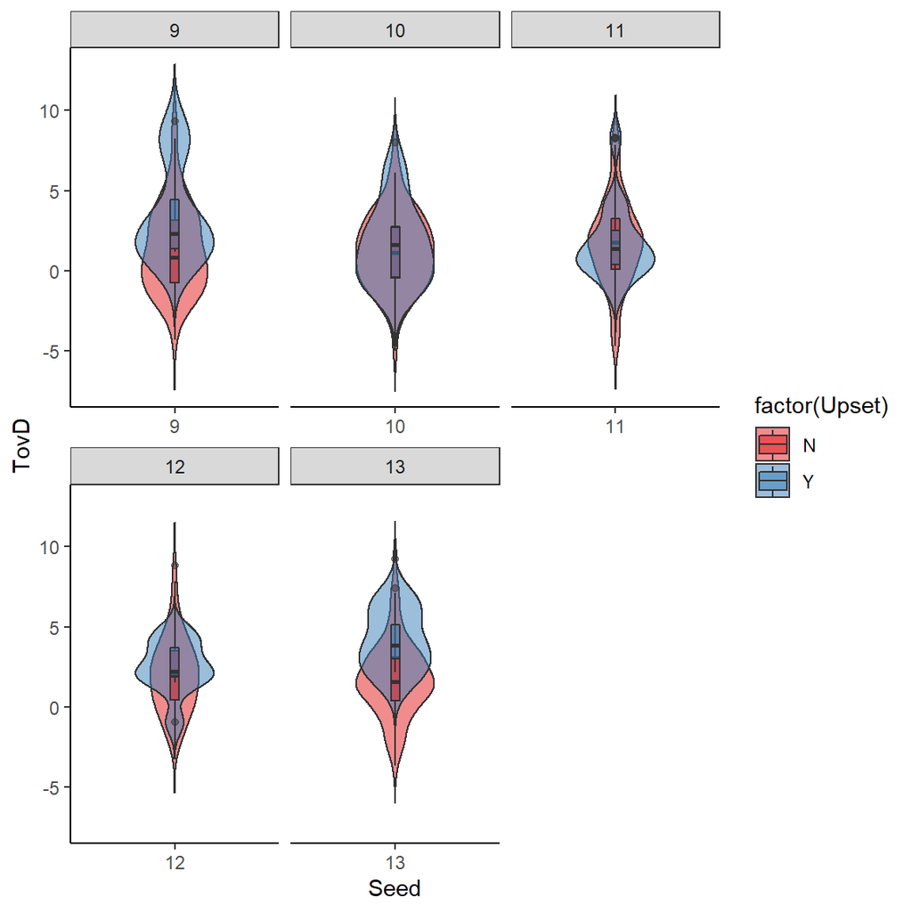

```r
plot_func(x="TovD")
```

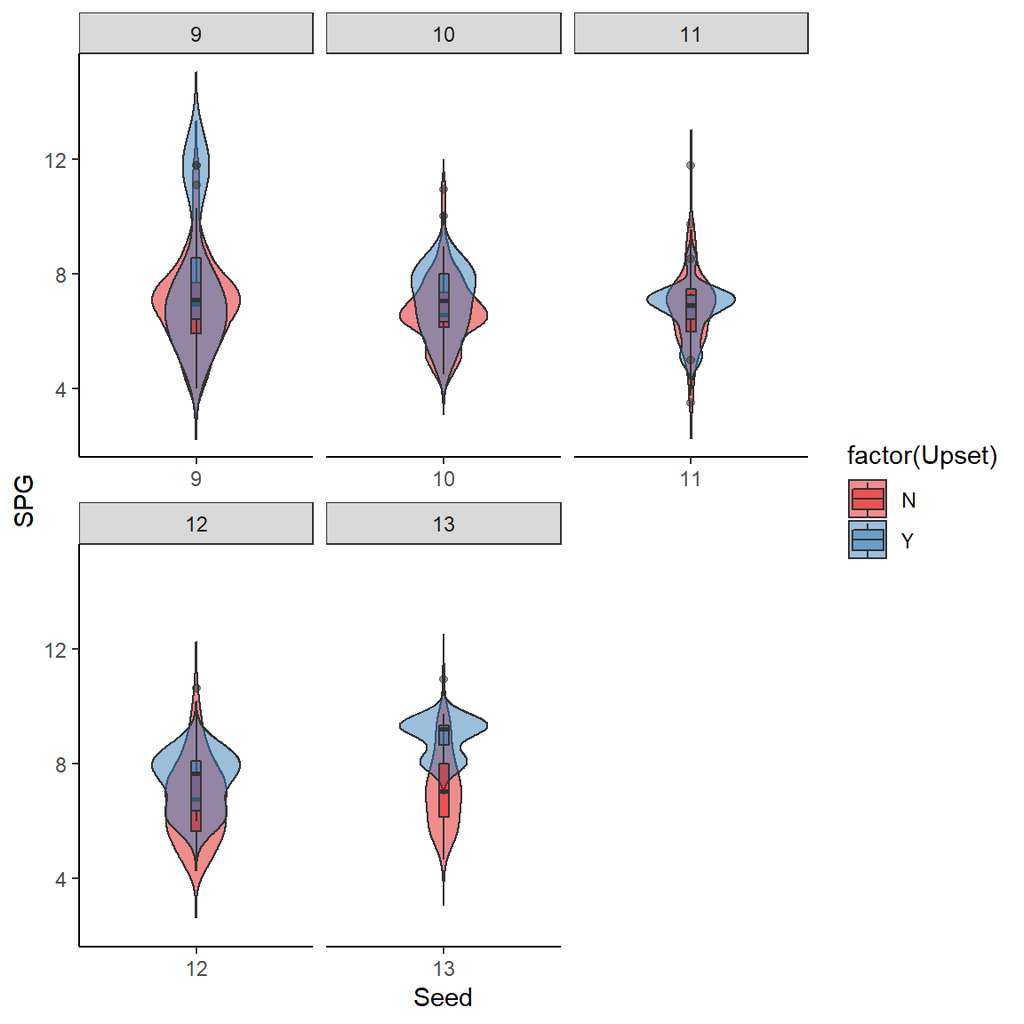

```r
plot_func(x="SPG")
```